# Introduccion a GREENREG

## Que es GREENREG

**GREENREG** es un paquete pensado para facilitar el ajuste, la validacion de supuestos y la interpretacion de modelos estadisticos comunes en ciencias agropecuarias y ambientales, sin tener que escribir a mano las pruebas de diagnostico cada vez.

Incluye funciones para:

- Regresion Lineal Simple (`greenreg_rls()`) y Multiple (`greenreg_rlm()`)
- Regresion Logistica (`greenreg_logistico()`) y de Poisson (`greenreg_reg_poisson()`)
- Modelos de series de tiempo: AR, MA, ARMA y ARIMA (`greenreg_modelo_ar()`, `greenreg_modelo_ma()`, `greenreg_modelo_arma()`, `greenreg_modelo_arima()`)
- `greenreg_analisis_datos()`, que sugiere que modelo usar segun el tipo de la variable respuesta

```r
library(GREENREG)
```

## Regresion Lineal Multiple

El flujo tipico es: ajustar el modelo, imprimirlo (para leer coeficientes, VIF y el veredicto de los supuestos) y graficarlo (para inspeccionar los diagnosticos visualmente).

```r
data(datos_rendimiento_maiz)

modelo <- greenreg_rlm(rendimiento_maiz_ton_ha ~ ., data = datos_rendimiento_maiz)
modelo
```

[output not shown]

`print()` reporta, en orden: los coeficientes con sus intervalos de confianza, el Factor de Inflacion de la Varianza (VIF) para detectar multicolinealidad, y una bateria de pruebas de supuestos (normalidad, homocedasticidad, independencia y linealidad) traducidas a un veredicto accionable.

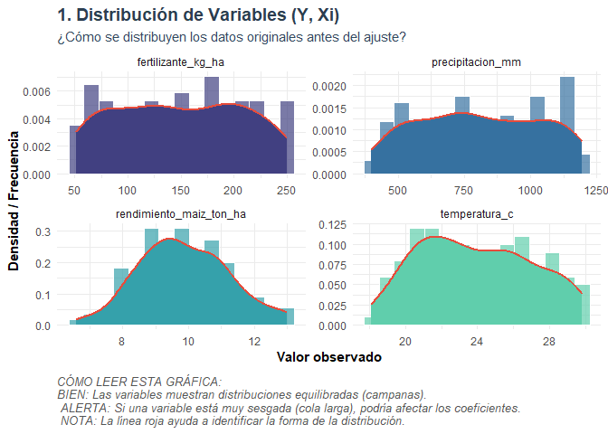

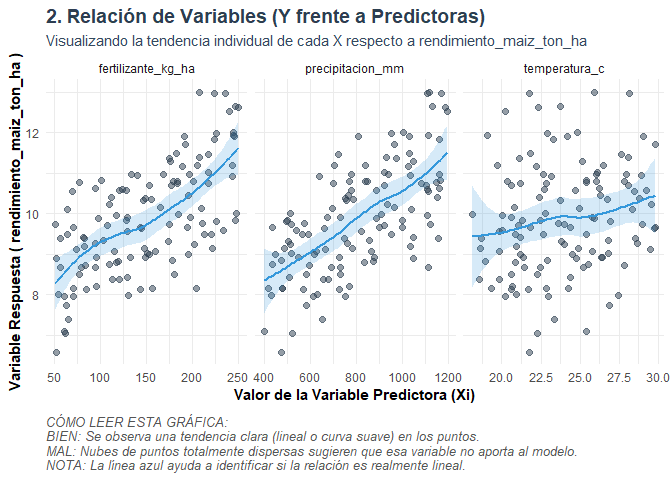

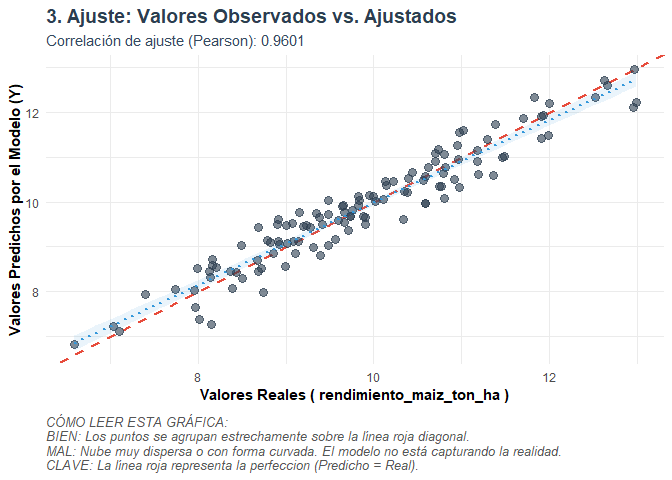

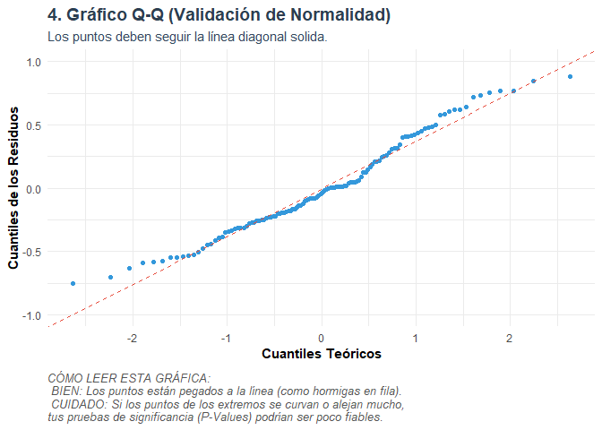

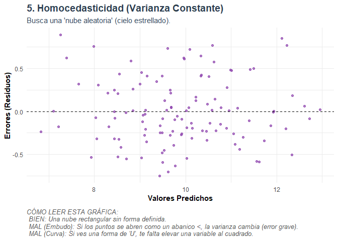

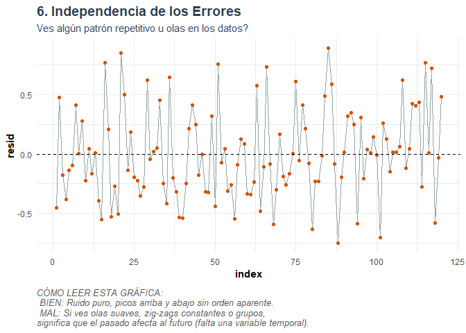

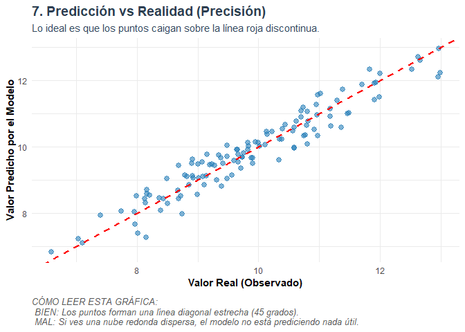

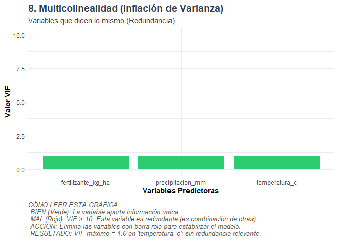

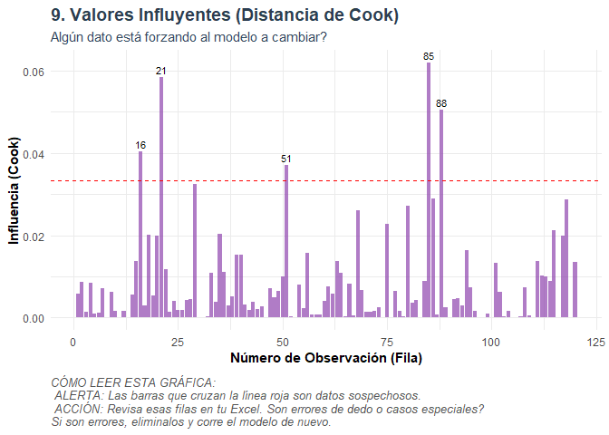

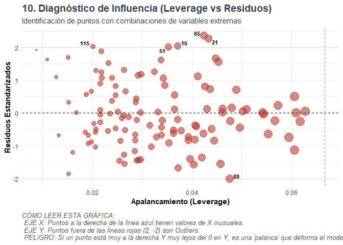

```r
plot(modelo)
```

`plot()` genera una secuencia de graficas de diagnostico: distribucion de variables, relacion Y vs. cada predictor, ajuste observado-vs-predicho, QQ-plot de normalidad, homocedasticidad, independencia, VIF, distancia de Cook y apalancamiento (leverage).

## Regresion Logistica

```r
data(datos_roya_cafe)

modelo_log <- greenreg_logistico(
  presencia_roya ~ humedad_relativa_pct + altitud_msnm + manejo_sombra,
  data = datos_roya_cafe
)
modelo_log
```

```
#>
#> ==========================================================
#>                REGRESIÓN LOGÍSTICA
#> ==========================================================
#>
#> --- 1. MODELO Y ECUACIÓN ---
#> Fórmula aplicada: presencia_roya ~ humedad_relativa_pct + altitud_msnm + manejo_sombra
#> Ecuación estimada:
#>  logit(p) = -27.484 + (0.306 * humedad_relativa_pct) + (-0.001 * altitud_msnm) + (-2.289 * manejo_sombra)
#>
#> --- 2. COEFICIENTES ESTIMADOS ---
#> Estimaciones en escala Logit (log-odds):
#>                        Estimate Std. Error z value Pr(>|z|)
#> (Intercept)          -2.748e+01  8.912e+00  -3.084  0.00204 **
#> humedad_relativa_pct  3.061e-01  9.733e-02   3.145  0.00166 **
#> altitud_msnm         -7.489e-04  1.089e-03  -0.688  0.49170
#> manejo_sombra        -2.289e+00  9.251e-01  -2.474  0.01335 *
#> ---
#> Signif. codes:  0 '***' 0.001 '**' 0.01 '*' 0.05 '.' 0.1 ' ' 1
#>
#> Interpretación en Odds Ratios (OR):
#>                          OR  2.5 % 97.5 % P-valor
#> humedad_relativa_pct 1.3581 1.1647 1.7239  0.0017
#> altitud_msnm         0.9993 0.9970 1.0014  0.4917
#> manejo_sombra        0.1014 0.0122 0.5231  0.0134
#>  NOTA: El intercepto se omite de esta tabla (su OR no tiene una
#>        interpretación útil; representa el caso base con predictores en 0).
#>  GUIA: OR > 1 Aumenta prob. | OR < 1 Disminuye prob.
#>
#> --- 3. EVALUACIÓN DEL MODELO ---
#> Prueba de Razon de Verosimilitud (LRT):
#>  Chi-cuadrado: 33.441 | GL: 3 | p-valor: 0.0000
#>  Resultado: Modelo Globalmente Significativo
#>
#> --- 4. BONDAD DE AJUSTE ---
#>  Log-Verosimilitud (LogLik): -21.9
#>  AIC (Criterio de Akaike):  51.801
#>  AUC (Área bajo la curva ROC): 0.95
#> * Pseudo R2 (McFadden) = 0.433. (Por encima de 0.4: revisa sobreajuste o separación casi perfecta antes de celebrar; la regla 0.2-0.4 no aplica aquí.)
#>  Prueba de Wald: Revisar asteriscos en la sección 2 (Significancia individual).
```

[output cut: 18 more lines]

```
#> --- 6. VERIFICACIÓN DE SUPUESTOS ---
#>  Linealidad en el Logit: Supuesta (Usar plot(x) para verificar gráficos de residuos).
#>  Independencia: Observaciones independientes asumidas por diseño.
#>  -  OKEY: El modelo es significativamente mejor que el nulo.
#>  -  OKEY: No hay multicolinealidad severa.
#>  -   ALERTA: Se detectaron casos influyentes (Distancia de Cook). Revisa los casos atípicos.
#>  -   ALERTA: Hay observaciones con Leverage alto (puntos atípicos en X). Usa plot() para ver el gráfico.
#>
#> --- 7. RESUMEN DEL MODELO ---
#> Conclusión rapida: Ejemplo de interpretación: La variable 'humedad_relativa_pct' es significativa. Su OR es 1.36, lo que significa que AUMENTA la probabilidad del evento.
#>
#>  ALERTA: El modelo presenta advertencias técnicas (Multicolinealidad, Puntos influyentes o Leverage).
#>  Se recomienda usar plot(nombre_del_objeto) para ver los gráficos de diagnóstico.
#>
#> ==========================================================
```

El resultado incluye los momios (Odds Ratio), la pseudo-R2 de McFadden, la matriz de confusion y el area bajo la curva ROC (AUC).

## Series de tiempo

```r
data(datos_anomalia_temperatura)

modelo_ts <- greenreg_modelo_ar(datos_anomalia_temperatura$anomalia_c, p = 2)
modelo_ts
```

```
#>
#> ==========================================================
#>      MODELO AUTORREGRESIVO AR(2)
#> ==========================================================
#>
#> --- 1. MODELO Y ECUACIÓN ---
#> Ecuación de Diferencias Estimada:
#>  Y(t) = -0.048 + (0.963 * Y(t-1)) + (-0.378 * Y(t-2)) + E(t)
#> AIC (Criterio de Akaike): 26.73
#>  NOTA: El intercepto representa el valor medio de la serie si es estacionaria.
#>
#> --- 2. COEFICIENTES ESTIMADOS (Parámetros Phi) ---
#>           Estimacion Std.Error  z.value P.valor
#> ar1          0.96319   0.05967 16.14326    0.00
#> ar2         -0.37801   0.05957 -6.34565    0.00
#> intercept   -0.04784   0.03899 -1.22689    0.22
#>
#>  Persistencia: El coeficiente AR1 es 0.96. Esto indica que tanto del valor de ayer (t-1) se transfiere a hoy.
#>  GUIA: Si |Phi| es cercano a 1, la serie tiene mucha memoria (persistencia).
#>
#> --- 3. IDENTIFICACIÓN DEL MODELO (Orden p) ---
#>  Orden seleccionado: p = 2
#>  Criterio ACF: Las autocorrelaciones decaen exponencialmente o de forma sinoidal.
#>  Criterio PACF: Los coeficientes de autocorrelación parcial se cortan despues del lag 2 .
#>  NOTA: Si ves barras significativas en PACF despues de p, podrias necesitar un orden mayor.
#>
#> --- 4. VERIFICACIÓN DE SUPUESTOS ---
#> A) Estacionariedad (Raíces Unitarias):
#>    - Módulos de raíces inversas: 0.615, 0.615
#>    -  CONCLUSIÓN: El modelo es ESTABLE (Estacionario). Puede usarse para predecir.
#>
#> B) Diagnóstico de Errores (E ~ RB):
#>   Media de los residuos: -0.0001 (Esperado: 0)
#>   No Autocorrelación (Ljung-Box p-valor): 0.0396  [lag=10, fitdf=2]
#>      ->  CONCLUSIÓN: Existe Autocorrelación. El modelo no capturó toda la dinámica (Faltan lags).
#>   Normalidad (Shapiro p-valor): 0.4942
#>      ->  CONCLUSIÓN: No se rechaza la normalidad de los errores (OKEY). Los intervalos de confianza son fiables.
#>
#> --- 5. RESUMEN DEL MODELO ---
#>  ADVERTENCIA: El modelo presenta deficiencias técnicas.
#>    Revisa si es necesario diferenciar la serie (d=1) o cambiar el orden p.
#>
#>  Usa plot(modelo) para visualizar la serie, ACF y raíces unitarias.
#> ==========================================================
```

`greenreg_modelo_ar()` (y sus analogos `greenreg_modelo_ma()`, `greenreg_modelo_arma()`, `greenreg_modelo_arima()`) reportan la estabilidad del modelo (raices inversas dentro del circulo unitario), y el diagnostico de residuos mediante la prueba de Ljung-Box (ruido blanco) y Shapiro-Wilk (normalidad).

## Que modelo debo usar

Cuando no es evidente que tipo de modelo conviene, `greenreg_analisis_datos()` inspecciona la variable respuesta y sugiere una opcion:

```r
greenreg_analisis_datos(datos_rendimiento_maiz, "rendimiento_maiz_ton_ha")
```

```
#>
#> Asistente de Análisis de Datos
#> ===========================================
#>    Base de datos: datos_rendimiento_maiz
#>    Objetivo: 'rendimiento_maiz_ton_ha'
#>    Observaciones: 120 | Predictoras: 3
#>
#> RECOMENDACIÓN AUTOMÁTICA:
#>    -> Sugerencia: Opción 1
#>    -> Motivo: Variable continua (Regresión Lineal).
#>
#> Opciones Disponibles:
#>    1. Regresión Lineal  * (Recomendado)
#>    2. Modelos GLM (Logística/Poisson)
#>    3. Series de Tiempo
#> -> Seleccion automática aplicada: 1
#>
#>  Analizando para Regresión Lineal...
#>
#>  ANÁLISIS COMPLETADO.
#> NOTA: El proceso stepwise (AIC) conservó todas las variables; no se eliminó ninguna.
#> --------------------------------------------------
#>  OPCIÓN A: Modelo con TODAS las variables
#> --------------------------------------------------
#> modelo_rlm_full <- greenreg_rlm(rendimiento_maiz_ton_ha ~ ., data = datos_rendimiento_maiz)
#> modelo_rlm_full
#> plot(modelo_rlm_full)
#> --------------------------------------------------
#>
#>  OPCIÓN B: Modelo OPTIMIZADO (Variables Seleccionadas)
#>    (Elimina variables que aportan ruido o son redundantes)
#> --------------------------------------------------
#> modelo_rlm_opt <- greenreg_rlm(rendimiento_maiz_ton_ha ~ precipitacion_mm + temperatura_c + fertilizante_kg_ha, data = datos_rendimiento_maiz)
#> modelo_rlm_opt
#> plot(modelo_rlm_opt)
#> --------------------------------------------------
```

[figure not shown]

## Para saber mas

Consulta la documentacion de cada funcion (por ejemplo, `?greenreg_rlm`) para el detalle de cada estadistico reportado y las referencias metodologicas (Montgomery et al., 2021; Box & Jenkins, 1970) en las que se basa el paquete.